# 2602113666_LabAssignment1

# Visualization

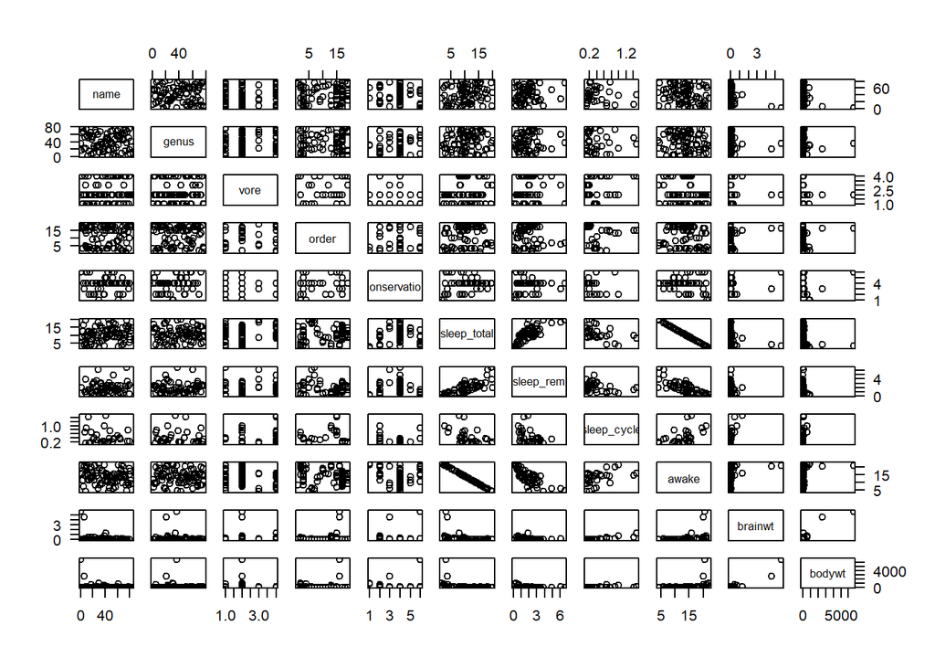

```r
plot(msleep, las = 1)
```

From the plot above I decided to explain more on the corelation between bodywt with vore, brainwt with vore, sleep_total with awake, and bodywt with bodywt.

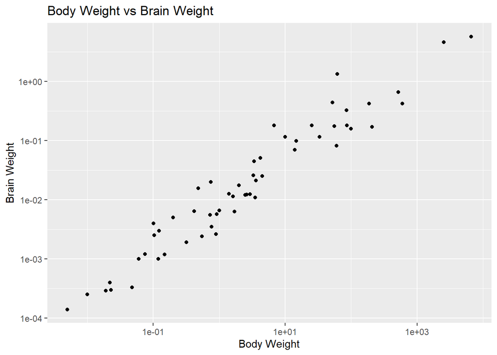

```r
ggplot(msleep, aes(x = bodywt, y = brainwt)) + geom_point() + labs(title = "Body Weight vs Brain Weight", x = "Body Weight", y = "Brain Weight") + scale_x_log10() + scale_y_log10()
```

From the Plot above we can see that there’s a postive realtionn between body weight and brain weight thus we can conlude that the heavier an animal is then its brain will also be heavier.

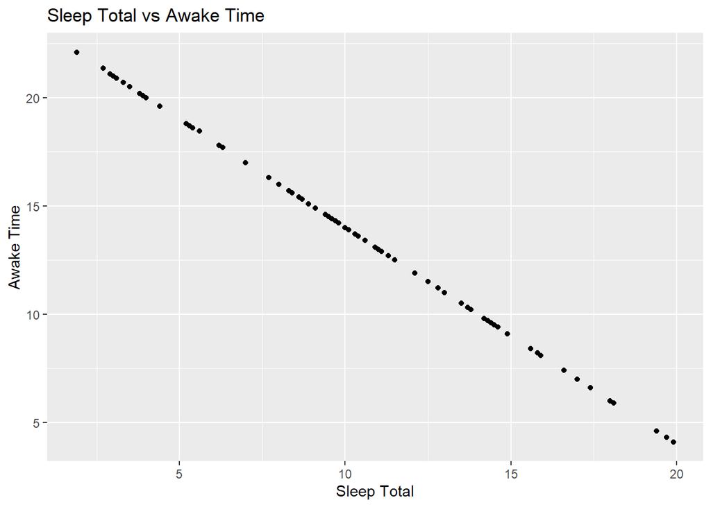

```r
ggplot(msleep, aes(x = sleep_total, y = awake)) + geom_point() + labs(title = "Sleep Total vs Awake Time", x = "Sleep Total", y = "Awake Time")
```

From the plot above we can see that Sleep Total and Awake time have a negative relatiosip. Meaning that the more an animal sleep then it will be awake lesser and vice versa.

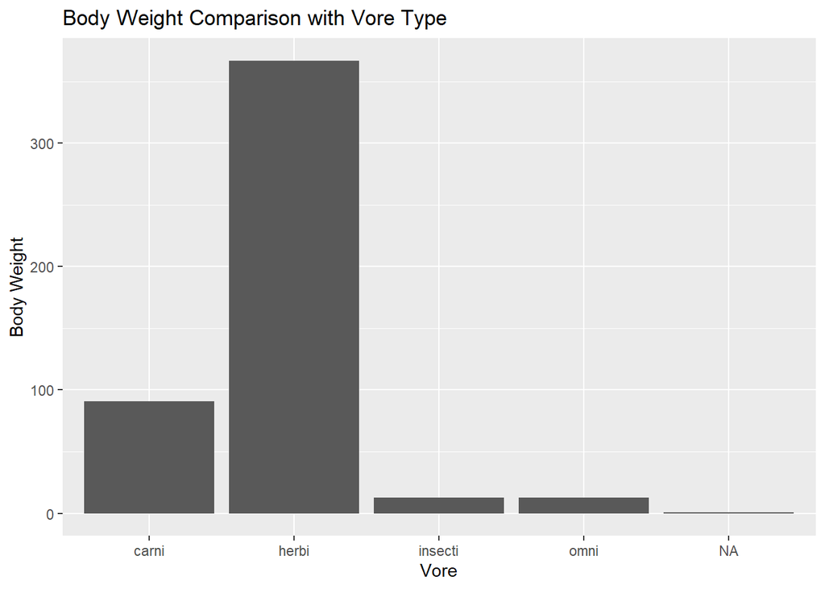

```r
ggplot(msleep, aes(x = vore, y = bodywt)) + geom_bar(stat = "summary", fun = "mean") + labs(title = "Body Weight Comparison with Vore Type", x = "Vore", y = "Body Weight" )
```

From the Graph above we can see that on average Herbivore have the heaviest body weight with Carnivore following. With Insectivore and Omnivore being the equally the lightest weight out of all.

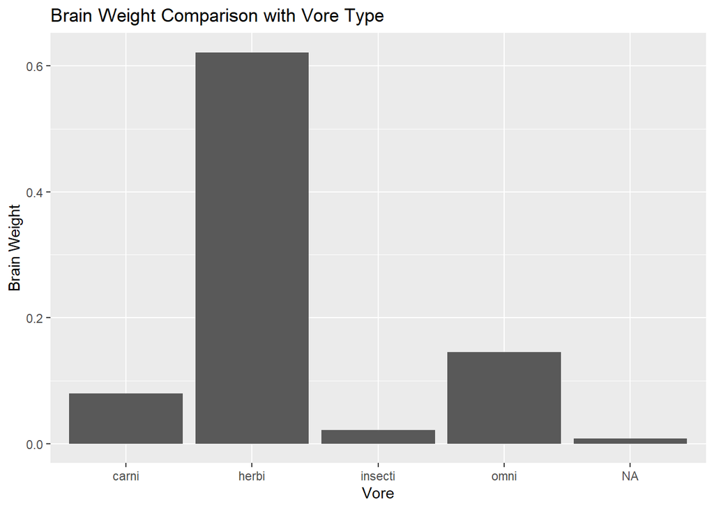

```r
ggplot(msleep, aes(x = vore, y = brainwt)) + geom_bar(stat = "summary", fun = "mean") + labs(title = "Brain Weight Comparison with Vore Type", x = "Vore", y = "Brain Weight" )
```

From the graph above we can also see that on average Herbivore having the heaviest brain out of all. WIth Omnivore folloing, having the second heaviest brain on average and Carnivore being the 3rd heaviest brain and insectivore having the lightest brain out of all on average.

# Anomalies

User Defined Function to Calculate How many anomalies

```r
extreme_values <- function(data) {

  # Calculate the IQR of the variable
  iqr <- IQR(data, na.rm = TRUE)

  # Calculate the lower and upper bounds for outliers
  lower_bound <- quantile(data, 0.25, na.rm = TRUE) - 1.5 * iqr
  upper_bound <- quantile(data, 0.75, na.rm = TRUE) + 1.5 * iqr

  # Count the number of extreme values
  extreme <- data[data < lower_bound | data > upper_bound]

  return(extreme)
}
```

```r
extreme_values(msleep$sleep_total)
```

```
## numeric(0)
```

There’s no Extreme Values in sleep_total Variable

```r
extreme_values(msleep$sleep_cycle)
```

```
##  [1]       NA       NA       NA       NA       NA       NA       NA       NA
##  [9]       NA       NA       NA       NA       NA       NA       NA       NA
## [17]       NA       NA 1.500000       NA       NA       NA       NA       NA
## [25]       NA       NA       NA       NA       NA 1.416667       NA       NA
## [33]       NA       NA       NA       NA       NA       NA       NA       NA
## [41]       NA       NA       NA       NA       NA       NA       NA       NA
## [49]       NA       NA       NA       NA       NA
```

The sleep_cycle Variable has 2 extreme values of 1.5 and 1.416667

```r
extreme_values(msleep$sleep_rem)
```

```
##  [1]  NA  NA  NA 4.9  NA  NA  NA 6.6  NA  NA  NA  NA  NA  NA  NA  NA  NA  NA 6.1
## [20]  NA  NA  NA  NA  NA  NA
```

The sleep_rem Variable has 3 extreme values of 4.9, 6.1, and 6.6.

```r
extreme_values(msleep$awake)
```

```
## numeric(0)
```

The awake Variable has no extreme value.

```r
extreme_values(msleep$brainwt)
```

```
##  [1]    NA    NA 0.423    NA    NA    NA    NA 4.603 0.655 0.419    NA    NA
## [13]    NA 0.325 1.320    NA 5.712    NA    NA    NA    NA    NA    NA 0.440
## [25]    NA    NA    NA    NA    NA    NA    NA    NA    NA    NA    NA
```

The brainwt Variable has 8 extreme values of 0.423, 4.603, and 0.655, 0.419, 0.325, 1.320, 5.712, 0.440.

```r
extreme_values(msleep$bodywt)
```

```
##  [1]  600.000 2547.000  521.000  187.000  899.995  800.000 6654.000  162.564
##  [9]  161.499  207.501  173.330
```

The bodywt Variable has 11 extreme values of 600.000, 2547.000, 521.000, 187.000, 899.995, 800.000, 6654.000, 162.564, 161.499, 207.501, 173.330.